# GEOGM0053: Midterm

LucWilson

2024-03-04

```r
# setting working directoty
#setwd('C:/Users/ni20171/OneDrive - University of Bristol/Msc Geographic Data Science & Spatial #Analytics/Machine Learning/MidTerm')
```

*Code chunk loads required libraries:*

```r
# loading required packages
library(tidyverse)
library(gridExtra) # for plotting histograms in a grid
library(car) # for vif()
library(caret) # for model training
library(randomForest) # for random forest
library(rpart) # for decision tree
library(rpart.plot) # for plotting decision trees
library(kableExtra) # for editing kables
library(vip) # for kknn variable importance
```

# Regression: What are the most important factors governing the popularity of a dog breed?

### Q1.a

*Code chunk reads in data:*

```r
# reading in the data (using tidyverse read_csv over base read.csv)
dogs = read_csv('midterm-data.csv')
head(dogs)
```

```
## # A tibble: 6 × 19
##   affection good_with_young_child…¹ good_with_other_dogs shedding grooming_needs
##       <dbl>                   <dbl>                <dbl>    <dbl>          <dbl>
## 1         5                       3                    3        3              1
## 2         5                       5                    5        5              3
## 3         5                       3                    5        3              2
## 4         5                       5                    5        3              2
## 5         5                       5                    3        2              3
## 6         5                       3                    3        1              5
## # ℹ abbreviated name: ¹good_with_young_children
## # ℹ 14 more variables: drool <dbl>, coat_type <chr>, coat_length <chr>,
## #   openness_to_strangers <dbl>, playfulness <dbl>, protectiveness <dbl>,
## #   adaptability <dbl>, trainability_level <dbl>, energy <dbl>, barking <dbl>,
## #   mental_stimulation_needs <dbl>, breed_clean <chr>, popularity <dbl>,
## #   editors_choice <dbl>
```

*Code chunk makes train and test data sets:*

```r
# splitting the data into training and testing sets
set.seed(1)

train = dogs %>%
  sample_frac(0.6) # small data set so using 60-40 split so that test data isn't too small

test = anti_join(dogs, train)
```

*Code chunk makes histograms to examine feature normality:*

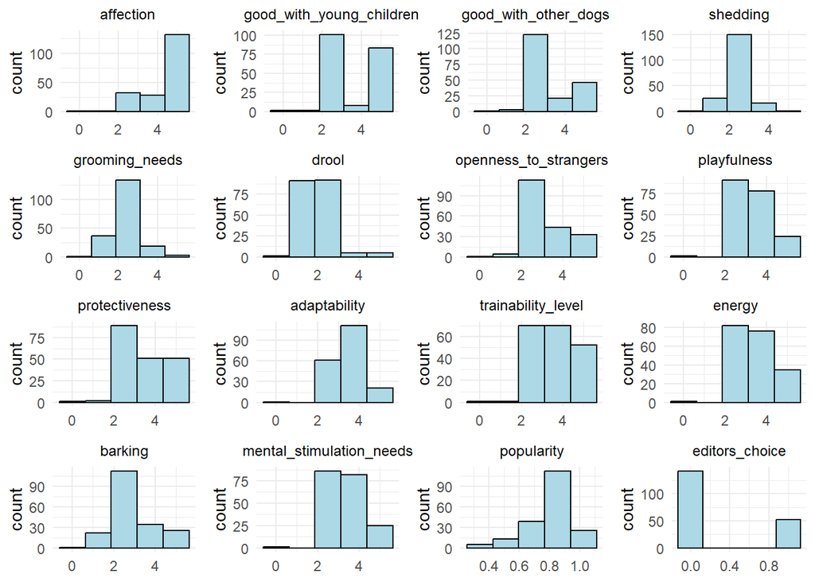

```r
# visually examining the normality of variables with histograms (assumption of linear regression)

# getting names of numeric columns
numeric_cols = c(dogs %>%
  select_if(is.numeric) %>%
  colnames())

# creating tibble with selected columns
numeric_dogs = dogs[numeric_cols]

# creating an empty list to store plots for grid.arrange()
histograms = list()

# setting plot size
plot_size = 3

# looping through columns to plot histograms in a grid
for (col in numeric_cols) {
  p = ggplot(data = numeric_dogs, aes(x = .data[[col]])) +
    geom_histogram(fill = 'lightblue',
                   color = 'black', # make bins clear
                   bins = 5 # lots of features are categorical 1-5
                   ) +
    ggtitle(col) + # making the titles the column names
    theme_minimal() +
    theme(plot.margin = ggplot2::margin(5, 5, 5, 5, 'pt'), # spacing the plots
          plot.title = element_text(size = 9, # title sizes
                                    hjust = 0.5 # centering titles
                                    )
  ) +
    xlab(NULL) # hiding x axis labels (same as titles)
  # appending list with plots
  histograms[[length(histograms) + 1]] = p
}

# Arrange plots in a grid and print
grid.arrange(grobs = histograms, # using list created above
             ncol = 4, # so its 4x4
             width = plot_size * 3, # setting plotting proportions
             height = plot_size * 5
             )
```

‘editors_choice’ is especially non-normal (categorical 1 or 0) which violates the assumptions of linear regression so it will be omitted.

Others factors which are especially non-normal: ‘affection’ (could be log-transformed) and ‘good_with_young_children’:

- since these features are categorical within the range of 1-5 it is not appropriate to apply a transformation. They will be included in the initial model to evaluate their importance but their non-normality means they significantly violate the assumptions of linear regression.

*Code chunk constructs initial linear model:*

```r
# making initial linear model
# using whole data set minus: 'editors_choice', 'coat_type', 'coat_length', 'breed_clean'
lm_1a1 = lm(popularity ~
              affection +
              good_with_young_children +
              good_with_other_dogs +
              shedding +
              grooming_needs +
              drool +
              openness_to_strangers +
              playfulness +
              protectiveness +
              adaptability +
              trainability_level +
              energy +
              barking +
              mental_stimulation_needs,
            data = dogs)
# printing model summary
summary(lm_1a1)
```

```
##
## Call:
## lm(formula = popularity ~ affection + good_with_young_children +
##     good_with_other_dogs + shedding + grooming_needs + drool +
##     openness_to_strangers + playfulness + protectiveness + adaptability +
##     trainability_level + energy + barking + mental_stimulation_needs,
##     data = dogs)
##
## Residuals:
##      Min       1Q   Median       3Q      Max
## -0.43170 -0.06021  0.02216  0.08176  0.24671
##
## Coefficients:
##                            Estimate Std. Error t value Pr(>|t|)
## (Intercept)               0.4670786  0.0788349   5.925 1.57e-08 ***
## affection                -0.0216584  0.0151478  -1.430  0.15452
## good_with_young_children  0.0053870  0.0112625   0.478  0.63301
## good_with_other_dogs     -0.0093177  0.0119025  -0.783  0.43476
## shedding                  0.0088541  0.0121118   0.731  0.46571
## grooming_needs            0.0216171  0.0106481   2.030  0.04382 *
## drool                     0.0204139  0.0111635   1.829  0.06912 .
## openness_to_strangers     0.0216985  0.0129973   1.669  0.09677 .
## playfulness               0.0519895  0.0189527   2.743  0.00670 **
## protectiveness            0.0256501  0.0114644   2.237  0.02650 *
## adaptability              0.0114376  0.0208250   0.549  0.58354
## trainability_level       -0.0019677  0.0130223  -0.151  0.88007
## energy                    0.0059136  0.0167133   0.354  0.72389
## barking                  -0.0259883  0.0090597  -2.869  0.00462 **
## mental_stimulation_needs  0.0009892  0.0190611   0.052  0.95867
## ---
## Signif. codes:  0 '***' 0.001 '**' 0.01 '*' 0.05 '.' 0.1 ' ' 1
##
## Residual standard error: 0.1295 on 179 degrees of freedom
## Multiple R-squared:  0.2259, Adjusted R-squared:  0.1654
## F-statistic: 3.732 on 14 and 179 DF,  p-value: 1.695e-05
```

### 1.b.

Looking at the model (lm_1a1) summary:

- The only variables significant to 95%: ‘grooming_needs’, ‘playfulness’, ‘protectiveness’, ‘barking’
- The variables significant to 90% (not 95): ‘drool’, ‘openness_to_strangers’

Using the whole data set for identifying useful features:

*Code chunk makes next linear model:*

```r
# further investigating linear model with only variables significant to +90%
lm_1a2 = lm(popularity ~
              grooming_needs +
              openness_to_strangers +
              playfulness +
              protectiveness +
              barking +
              drool,
   data = dogs)
# printing model summary
summary(lm_1a2)
```

```
##
## Call:
## lm(formula = popularity ~ grooming_needs + openness_to_strangers +
##     playfulness + protectiveness + barking + drool, data = dogs)
##
## Residuals:
##      Min       1Q   Median       3Q      Max
## -0.41052 -0.05398  0.01901  0.08865  0.21073
##
## Coefficients:
##                        Estimate Std. Error t value Pr(>|t|)
## (Intercept)            0.453303   0.064124   7.069 3.01e-11 ***
## grooming_needs         0.020786   0.009847   2.111 0.036099 *
## openness_to_strangers  0.018315   0.011910   1.538 0.125800
## playfulness            0.051802   0.014930   3.470 0.000647 ***
## protectiveness         0.026545   0.010032   2.646 0.008838 **
## barking               -0.025106   0.008740  -2.873 0.004541 **
## drool                  0.018958   0.010017   1.893 0.059963 .
## ---
## Signif. codes:  0 '***' 0.001 '**' 0.01 '*' 0.05 '.' 0.1 ' ' 1
##
## Residual standard error: 0.128 on 187 degrees of freedom
## Multiple R-squared:  0.2097, Adjusted R-squared:  0.1844
## F-statistic: 8.272 on 6 and 187 DF,  p-value: 5.935e-08
```

```r
# printing multicollinearity
vif(lm_1a2)
```

```
##        grooming_needs openness_to_strangers           playfulness
##              1.037743              1.422341              1.459156
##        protectiveness               barking                 drool
##              1.086845              1.123459              1.100672
```

- ‘openness_to_strangers’ no longer significant so it is being removed.
- ‘drool’ is only significant to 90%, so it is being removed too.

The next model will use the remaining features.

Now there are fewer terms, looking to see if there are any useful interaction terms:

*Code chunk makes next linear model with interaction terms:*

```r
# examining interactions now
lm_1a3 = lm(popularity ~
              grooming_needs *
              playfulness *
              protectiveness *
              barking,
   data = dogs)
# printing model summary
summary(lm_1a3)
```

```
##
## Call:
## lm(formula = popularity ~ grooming_needs * playfulness * protectiveness *
##     barking, data = dogs)
##
## Residuals:
##      Min       1Q   Median       3Q      Max
## -0.40460 -0.04969  0.01799  0.08212  0.25392
##
## Coefficients:
##                                                    Estimate Std. Error t value
## (Intercept)                                        0.633319   0.123502   5.128
## grooming_needs                                    -0.315457   0.286746  -1.100
## playfulness                                        0.132851   0.095464   1.392
## protectiveness                                     0.016967   0.114884   0.148
## barking                                           -0.475039   0.190940  -2.488
## grooming_needs:playfulness                         0.014671   0.081848   0.179
## grooming_needs:protectiveness                      0.084171   0.083163   1.012
## playfulness:protectiveness                        -0.014946   0.044340  -0.337
## grooming_needs:barking                             0.267418   0.122983   2.174
## playfulness:barking                                0.065541   0.050951   1.286
## protectiveness:barking                             0.105456   0.056867   1.854
## grooming_needs:playfulness:protectiveness         -0.007709   0.026003  -0.296
## grooming_needs:playfulness:barking                -0.037619   0.031199  -1.206
## grooming_needs:protectiveness:barking             -0.066884   0.031111  -2.150
## playfulness:protectiveness:barking                -0.017234   0.015830  -1.089
## grooming_needs:playfulness:protectiveness:barking  0.010722   0.008297   1.292
##                                                   Pr(>|t|)
## (Intercept)                                       7.59e-07 ***
## grooming_needs                                      0.2728
## playfulness                                         0.1658
## protectiveness                                      0.8828
## barking                                             0.0138 *
## grooming_needs:playfulness                          0.8580
## grooming_needs:protectiveness                       0.3129
## playfulness:protectiveness                          0.7365
## grooming_needs:barking                              0.0310 *
## playfulness:barking                                 0.2000
## protectiveness:barking                              0.0653 .
## grooming_needs:playfulness:protectiveness           0.7672
## grooming_needs:playfulness:barking                  0.2295
## grooming_needs:protectiveness:barking               0.0329 *
## playfulness:protectiveness:barking                  0.2778
## grooming_needs:playfulness:protectiveness:barking   0.1979
## ---
## Signif. codes:  0 '***' 0.001 '**' 0.01 '*' 0.05 '.' 0.1 ' ' 1
##
## Residual standard error: 0.1238 on 178 degrees of freedom
## Multiple R-squared:  0.2969, Adjusted R-squared:  0.2376
## F-statistic:  5.01 on 15 and 178 DF,  p-value: 3.56e-08
```

‘grooming_needs:protectiveness:barking’ and ‘grooming_needs:barking’ are significant to 95% so investigating this further.

*Code chunk makes next linear model, testing the significant interaction terms:*

```r
# creating new linear model with the additional interaction terms
lm_1a4 = lm(popularity ~
              grooming_needs +
              playfulness +
              protectiveness +
              barking +
              grooming_needs:protectiveness:barking +
              grooming_needs:barking,
   data = dogs)
# printing model summary
summary(lm_1a4)
```

```
##
## Call:
## lm(formula = popularity ~ grooming_needs + playfulness + protectiveness +
##     barking + grooming_needs:protectiveness:barking + grooming_needs:barking,
##     data = dogs)
##
## Residuals:
##      Min       1Q   Median       3Q      Max
## -0.41760 -0.04861  0.02290  0.08428  0.24092
##
## Coefficients:
##                                        Estimate Std. Error t value Pr(>|t|)
## (Intercept)                            0.489115   0.084251   5.805 2.71e-08 ***
## grooming_needs                        -0.073442   0.027500  -2.671 0.008238 **
## playfulness                            0.064917   0.012414   5.229 4.53e-07 ***
## protectiveness                         0.082623   0.017275   4.783 3.50e-06 ***
## barking                               -0.093164   0.019337  -4.818 2.99e-06 ***
## grooming_needs:barking                 0.062527   0.013450   4.649 6.29e-06 ***
## grooming_needs:protectiveness:barking -0.008052   0.002173  -3.706 0.000277 ***
## ---
## Signif. codes:  0 '***' 0.001 '**' 0.01 '*' 0.05 '.' 0.1 ' ' 1
##
## Residual standard error: 0.1234 on 187 degrees of freedom
## Multiple R-squared:  0.266,  Adjusted R-squared:  0.2425
## F-statistic:  11.3 on 6 and 187 DF,  p-value: 9.344e-11
```

```r
# checking multicollinearity
vif(lm_1a4)
```

```
##                        grooming_needs                           playfulness
##                              8.715190                              1.086247
##                        protectiveness                               barking
##                              3.469769                              5.921087
##                grooming_needs:barking grooming_needs:protectiveness:barking
##                             36.547109                             19.091229
```

- Adjusted R squared has increased (from lm_1a2:0.1844 to lm_1a4:0.2425)
- Interaction terms are high significance.

As expected, collinearity has increased. Generally VIF>6 is considered unacceptable.

The only way to lower the VIF of the interaction terms is to have them without the original terms. Investigating to see how this model would perform:

*Code chunk makes next linear model:*

```r
# creating new linear model without base terms for interaction terms to test if this is better
lm_1a5 = lm(popularity ~
              playfulness +
              grooming_needs:barking +
              grooming_needs:protectiveness:barking,
   data = dogs)
# printing model summary
summary(lm_1a5)
```

```
##
## Call:
## lm(formula = popularity ~ playfulness + grooming_needs:barking +
##     grooming_needs:protectiveness:barking, data = dogs)
##
## Residuals:
##      Min       1Q   Median       3Q      Max
## -0.44749 -0.05342  0.03450  0.09375  0.21104
##
## Coefficients:
##                                        Estimate Std. Error t value Pr(>|t|)
## (Intercept)                            0.603682   0.049594  12.173  < 2e-16 ***
## playfulness                            0.053091   0.013399   3.962 0.000105 ***
## grooming_needs:barking                -0.003464   0.005771  -0.600 0.549115
## grooming_needs:barking:protectiveness  0.001294   0.001286   1.007 0.315347
## ---
## Signif. codes:  0 '***' 0.001 '**' 0.01 '*' 0.05 '.' 0.1 ' ' 1
##
## Residual standard error: 0.1362 on 190 degrees of freedom
## Multiple R-squared:  0.09068,    Adjusted R-squared:  0.07632
## F-statistic: 6.316 on 3 and 190 DF,  p-value: 0.0004178
```

```r
# checking multicollinearity
vif(lm_1a5)
```

```
##                           playfulness                grooming_needs:barking
##                              1.037759                              5.518616
## grooming_needs:barking:protectiveness
##                              5.481909
```

- The adjusted R squared drops significantly.
- To keep the multicollinearty (VIF scores) acceptable the model performs worse.
- Therefore removing the interaction terms.

*Code chunk makes final linear model:*

```r
# regenerating lm_1a2 without 'drool' and 'openness_to_strangers'
lm_1a6 = lm(popularity ~
              grooming_needs +
              playfulness +
              protectiveness +
              barking,
   data = dogs)
# printing model summary
summary(lm_1a6)
```

```
##
## Call:
## lm(formula = popularity ~ grooming_needs + playfulness + protectiveness +
##     barking, data = dogs)
##
## Residuals:
##      Min       1Q   Median       3Q      Max
## -0.42634 -0.05018  0.02132  0.09009  0.26065
##
## Coefficients:
##                 Estimate Std. Error t value Pr(>|t|)
## (Intercept)     0.511807   0.060795   8.419 9.34e-15 ***
## grooming_needs  0.021515   0.009917   2.170  0.03128 *
## playfulness     0.062015   0.013008   4.767 3.72e-06 ***
## protectiveness  0.028587   0.009807   2.915  0.00399 **
## barking        -0.027438   0.008711  -3.150  0.00190 **
## ---
## Signif. codes:  0 '***' 0.001 '**' 0.01 '*' 0.05 '.' 0.1 ' ' 1
##
## Residual standard error: 0.1296 on 189 degrees of freedom
## Multiple R-squared:  0.1812, Adjusted R-squared:  0.1639
## F-statistic: 10.46 on 4 and 189 DF,  p-value: 1.133e-07
```

```r
# checking multicollinearity
vif(lm_1a6)
```

```
## grooming_needs    playfulness protectiveness        barking
##       1.026717       1.080518       1.013190       1.088520
```

##### All features are now significant (95%), and non-collinear (VIF<1.1).

##### Therefore the most useful features to predict the popularity of a dog breed are:

- grooming_needs
- playfulness
- protectiveness
- barking

### 1.c.

*Code chunk fits linear model to training data:*

```r
# fitting to the training data set
lm_1c = lm(popularity ~ grooming_needs +
              playfulness +
              protectiveness +
              barking,
   data = train)
# printing model summary
summary(lm_1c)
```

```
##
## Call:
## lm(formula = popularity ~ grooming_needs + playfulness + protectiveness +
##     barking, data = train)
##
## Residuals:
##      Min       1Q   Median       3Q      Max
## -0.39888 -0.04750  0.01697  0.08524  0.21830
##
## Coefficients:
##                 Estimate Std. Error t value Pr(>|t|)
## (Intercept)     0.538212   0.067942   7.922 1.96e-12 ***
## grooming_needs  0.005791   0.013055   0.444 0.658203
## playfulness     0.062079   0.017029   3.645 0.000408 ***
## protectiveness  0.021218   0.011990   1.770 0.079533 .
## barking        -0.013825   0.011010  -1.256 0.211871
## ---
## Signif. codes:  0 '***' 0.001 '**' 0.01 '*' 0.05 '.' 0.1 ' ' 1
##
## Residual standard error: 0.1263 on 111 degrees of freedom
## Multiple R-squared:  0.1609, Adjusted R-squared:  0.1307
## F-statistic: 5.322 on 4 and 111 DF,  p-value: 0.0005866
```

```r
# checking multicollinearity
vif(lm_1c)
```

```
## grooming_needs    playfulness protectiveness        barking
##       1.080599       1.165190       1.090064       1.122311
```

- significance scores have changed significantly: symptom of small, variable data set

*Code chunk gets out-of-sample predictions:*

```r
# applying lm_1c to test data for cross validation:
test_predictions = predict(lm_1c, newdata = test)
```

*Code chunk makes function to calculate mean squared error (MSE):*

```r
# defining MSE function
MSE = function(actual, predicted) {
  mse = mean((actual - predicted)^2)
  return(mse)
}
```

*Code chunk calculates, and prints, the out-of-sample MSE, R squared, and adjusted R squared for the linear model:*

```r
# using MSE function to calculate MSE of lm_1c
mse_lm_1c = MSE(actual = test$popularity,
                 predicted = test_predictions)
cat('The out-of-sample mean squared error (MSE) is: ', mse_lm_1c, '\n')
```

```
## The out-of-sample mean squared error (MSE) is:  0.01922457
```

```r
# getting out-f-sample adjusted R squared for lm_1c
out_of_samp_Rsq = 1 - sum((test$popularity -
                                     test_predictions)^2) /
  sum((test$popularity -
         mean(test$popularity))^2)

# adjusting R squared for data size:
n = nrow(test) # number of rows
k = 4 # number of features

# getting adjusted R squared (more useful for comparing models with different number of features)
out_of_samp_adj_Rsq = 1 - ((1 - out_of_samp_Rsq) * (n - 1) / (n - k - 1))

# printing answers
# (question specifies R squared but I will use adjusted R squared for model comparisons so printing both)
cat('The out-of-sample R squared is:', out_of_samp_Rsq, 'and the adjusted out-of-sample R squared is: ',out_of_samp_adj_Rsq, '\n')
```

```
## The out-of-sample R squared is: 0.1479749 and the adjusted out-of-sample R squared is:  0.1012885
```

### 1.d.

*Code chunk adds ‘is_terrier’ to the data:*

```r
# creating 'is_terrier' variable (one-hot encoded)
dogs$is_terrier = as.integer(grepl('Terrier', dogs$breed_clean))

# doing for test and train too
train$is_terrier = as.integer(grepl('Terrier', train$breed_clean))
test$is_terrier = as.integer(grepl('Terrier', test$breed_clean))
```

The initial check for bias is a visual examination of residuals: (I am looking to see if the residuals of ‘is_terrier’ points are different)

*Code chunk generates colour-coded plot of residuals, by ‘is_terrier’ feature:*

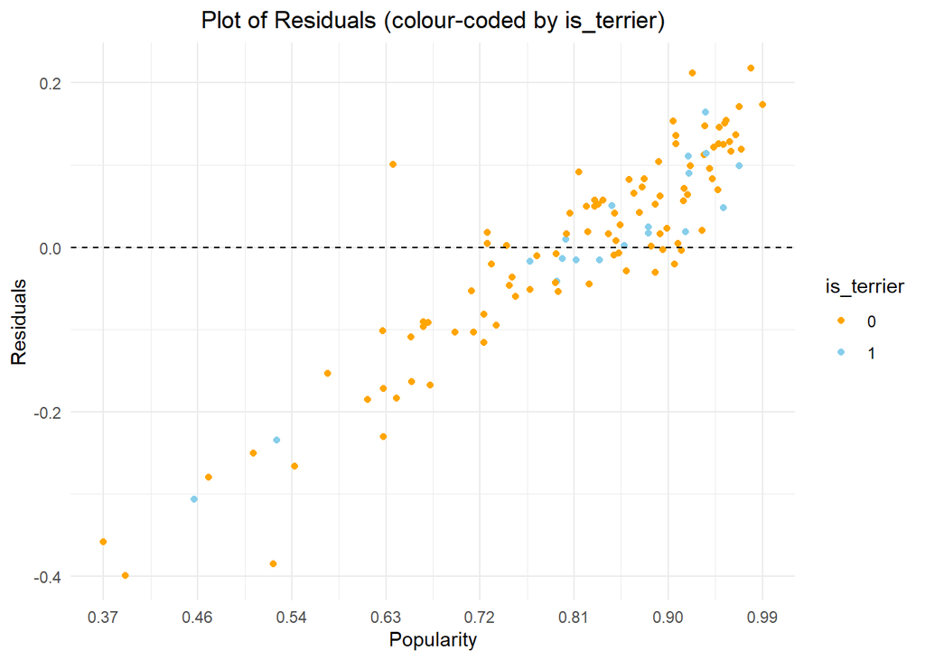

```r
# getting residuals for lm_1c
resid_lm_1c = residuals(lm_1c)

# making data frame for plotting
resid_lm_1c_1d = data.frame(residuals = resid_lm_1c,
                            is_terrier = factor(train$is_terrier), # categorical
                            popularity = train$popularity)

# Creating a plot of residuals colour-coded by is_terrier
ggplot(resid_lm_1c_1d, aes(x = popularity, y = residuals, color = is_terrier)) +
  geom_point() +
  geom_hline(yintercept = 0, # adding line where residuals should centre around
             linetype = 'dashed',
             color = 'black') +
  labs(x = 'Popularity',
       y = 'Residuals',
       title = 'Plot of Residuals (colour-coded by is_terrier)') +
  theme_minimal() +
  scale_x_continuous(breaks = seq(min(as.numeric(resid_lm_1c_1d$popularity)),
                                max(as.numeric(resid_lm_1c_1d$popularity)),
                                length.out = 8),
                     labels = scales::number_format(accuracy = 0.01)) + # rounding x-axis labels to 2dp
                     scale_color_manual(values = c("orange", "skyblue"))  +
  theme(plot.title = element_text(hjust = 0.5))  # centering title
```

*Code chunk regenerates the linear model with ‘is_terrier’ added:*

```r
# no obvious bias with is_terrier in the model.
# adding is_terrier to the model to see any changes
lm_1d = lm(popularity ~ grooming_needs +
              playfulness +
              protectiveness +
              barking +
             is_terrier,
   data = train)
summary(lm_1d)
```

```
##
## Call:
## lm(formula = popularity ~ grooming_needs + playfulness + protectiveness +
##     barking + is_terrier, data = train)
##
## Residuals:
##      Min       1Q   Median       3Q      Max
## -0.39867 -0.04769  0.01696  0.08442  0.21903
##
## Coefficients:
##                 Estimate Std. Error t value Pr(>|t|)
## (Intercept)     0.540048   0.068739   7.857 2.86e-12 ***
## grooming_needs  0.005416   0.013221   0.410 0.682864
## playfulness     0.062256   0.017121   3.636 0.000423 ***
## protectiveness  0.020697   0.012270   1.687 0.094493 .
## barking        -0.014087   0.011121  -1.267 0.207923
## is_terrier      0.007337   0.033199   0.221 0.825508
## ---
## Signif. codes:  0 '***' 0.001 '**' 0.01 '*' 0.05 '.' 0.1 ' ' 1
##
## Residual standard error: 0.1269 on 110 degrees of freedom
## Multiple R-squared:  0.1613, Adjusted R-squared:  0.1232
## F-statistic: 4.231 on 5 and 110 DF,  p-value: 0.001482
```

```r
vif(lm_1d)
```

```
## grooming_needs    playfulness protectiveness        barking     is_terrier
##       1.098723       1.167738       1.131880       1.135287       1.087615
```

```r
# r2 has dropped slightly
```

*Code chunk generates out-of-sample MSE and R squared of the new linear model:*

```r
# checking MSE
test_predictions_1d = predict(lm_1d, newdata = test)

mse_lm_1d = MSE(actual = test$popularity,
                 predicted = test_predictions_1d)
cat('The out-of-sample mean squared error (MSE) is:', mse_lm_1d, '\n')
```

```
## The out-of-sample mean squared error (MSE) is: 0.01931453
```

```r
# getting out of sample R squared
out_of_samp_Rsq_1d = 1 - sum((test$popularity -
                                     test_predictions_1d)^2) /
  sum((test$popularity -
         mean(test$popularity))^2)

# adjusting R squared for data size:
n = nrow(test) # number of rows
k = 5 # number of features

out_of_samp_adj_Rsq_1d = 1 - ((1 - out_of_samp_Rsq_1d) * (n - 1) / (n - k - 1))

cat('The out-of-sample adjusted R squared is:', out_of_samp_adj_Rsq_1d, '\n')
```

```
## The out-of-sample adjusted R squared is: 0.08454251
```

*Code chunk generates a results table to compare model performances with and without ‘is_terrier’ feature:*

```r
# making kable to compare with and without is_terrier models MSE and R squared

# making dataframe to store model results
regression_results = data.frame(
  Model = c('lm_1c', 'lm_1d'),
  OutofSample_MSE = c(mse_lm_1c, mse_lm_1d),
  OutofSample_Adj_R_squared = c(out_of_samp_adj_Rsq, out_of_samp_adj_Rsq_1d)
)
# rounding values to 4dp
regression_results$OutofSample_MSE = sprintf('%.4f', regression_results$OutofSample_MSE)
regression_results$OutofSample_Adj_R_squared = sprintf('%.4f', regression_results$OutofSample_Adj_R_squared)

# making kable
kable(regression_results,
      caption = NULL,
      col.names = c('Model', 'Out-of-Sample MSE', 'Out-of-Sample Adjusted R squared'),
      align = 'c',
      format = 'html',
      table.attr = 'style="width:60%;margin:auto;"'   # centering kable
)%>%
  kable_styling(bootstrap_options = c('bordered'))
```

| Model | Out-of-Sample MSE | Out-of-Sample Adjusted R squared |
| --- | --- | --- |
| lm_1c | 0.0192 | 0.1013 |
| lm_1d | 0.0193 | 0.0845 |

There was no visual differences between the predictions of ‘is_terrier’ dogs and the other data points AND there was no significant change in model MSE. There was a slight change in Out-of-Sample Adjusted R squared however the values are close to 0 (<0.11) so the change is not regarded as significant.

##### The conclusion is therefore that there is no model bias against terriers.

- Conceptually, there could have been a difference if the popularity of terrier dogs is determined differently to the mean of how other breeds.
- For example: if terrier dogs have a reputation for being dangerous then the playfulness variable might act differently for them etc.

### 2.a.

*Code chunk subsets data to only the identified ‘useful’ features:*

```r
# sub-setting specific columns
cols_2a = c('popularity',
            'grooming_needs',
              'playfulness',
              'protectiveness',
              'barking')
dogs_2a = dogs[, cols_2a]
```

*Code chunk regenerates test and train data with the subsetted data set:*

```r
# making test and training data of dogs_2a df
set.seed(1)

train_2a = dogs_2a %>%
  sample_frac(0.6)

test_2a = anti_join(dogs_2a, train_2a)
```

*Code chunk sets a control parameter for model cross validation:*

```r
# setting control parameters for cross validation
ctrl = trainControl(method = 'cv', number = 5, verboseIter = FALSE)
```

*Code chunk fits random forest model:*

```r
# fitting random forest (training data)
rf_2a = train(popularity ~ grooming_needs+
              playfulness+
              protectiveness+
              barking,
              data = train_2a,
              method = 'rf',
              trControl = ctrl,
              ntree = 1000)
rf_2a
```

```
## Random Forest
##
## 116 samples
##   4 predictor
##
## No pre-processing
## Resampling: Cross-Validated (5 fold)
## Summary of sample sizes: 92, 95, 92, 93, 92
## Resampling results across tuning parameters:
##
##   mtry  RMSE       Rsquared   MAE
##   2     0.1343102  0.1072393  0.1044884
##   3     0.1366563  0.1203185  0.1057774
##   4     0.1385515  0.1187952  0.1072412
##
## RMSE was used to select the optimal model using the smallest value.
## The final value used for the model was mtry = 2.
```

*Code chunk generates out-of-sample MSE for random forest model:*

```r
# getting predictions from rf_2a
predictions_2a = predict(rf_2a, newdata = test_2a)

# getting the MSE of rf_2a
rf_2a_MSE = MSE(actual = test_2a$popularity,
                 predicted = predictions_2a)

# getting R squared
rsquared_2a <- 1 - sum((test_2a$popularity - predictions_2a)^2) / sum((test_2a$popularity - mean(test_2a$popularity))^2)
cat('The out-of-sample R squared is:', rsquared_2a, '\n')
```

```
## The out-of-sample R squared is: 0.188438
```

```r
# adjusting R squared for data size:
n = nrow(test_2a) # number of rows
k = 4 # number of features

out_of_samp_adj_Rsq_2a = 1 - ((1 - rsquared_2a) * (n - 1) / (n - k - 1))
cat('The out-of-sample adjusted R squared is:', out_of_samp_adj_Rsq_2a, '\n')
```

```
## The out-of-sample adjusted R squared is: 0.1439689
```

*Code chunk appends result table to include the random forest model:*

```r
# appending results data frame
regression_results = rbind(regression_results, c('rf_2a', rf_2a_MSE, out_of_samp_adj_Rsq_2a))

# resetting as numeric
regression_results$OutofSample_MSE = as.numeric(regression_results$OutofSample_MSE)
regression_results$OutofSample_Adj_R_squared = as.numeric(regression_results$OutofSample_Adj_R_squared)

# setting to 4dp
regression_results$OutofSample_MSE = sprintf('%.4f', regression_results$OutofSample_MSE)
regression_results$OutofSample_Adj_R_squared = sprintf('%.4f', regression_results$OutofSample_Adj_R_squared)

# making updated kable
kable(regression_results,
      caption = NULL,
      col.names = c('Model', 'Out-of-Sample MSE', 'Out-of-Sample Adjusted R squared'),
      align = 'c',
      format = 'html',
      table.attr = 'style="width:60%;margin:auto;"' ) %>% # centring kable
  kable_styling(bootstrap_options = c('bordered'))
```

| Model | Out-of-Sample MSE | Out-of-Sample Adjusted R squared |
| --- | --- | --- |
| lm_1c | 0.0192 | 0.1013 |
| lm_1d | 0.0193 | 0.0845 |
| rf_2a | 0.0183 | 0.1440 |

### 2.b.

*Code chunk prints the importance of the variables in the random forest model:*

```r
# checking variable importance
var_importance = varImp(rf_2a)
# Print variable importance
print(var_importance)
```

```
## rf variable importance
##
##                Overall
## barking         100.00
## playfulness      88.66
## protectiveness   11.56
## grooming_needs    0.00
```

*Code chunk prints the importance of the variables in the linear model:*

```r
# printing for linear model too, for comparison
var_importance_lm_1c = varImp(lm_1c)
print(var_importance_lm_1c)
```

```
##                  Overall
## grooming_needs 0.4435887
## playfulness    3.6454887
## protectiveness 1.7696404
## barking        1.2556730
```

The variable importance is not the same between the linear model (lm_1c) and the random forest model (rf_2a). The ‘best’ predictor for the random forest model was ‘barking’ whereas the most ‘best’ predictor for the linear model was ‘playfulness.’

The two models did agree that ‘grooming_needs’ was the ‘worst’ predictor of those used.

### 2.c.

*Code chunk regenerates training and test data with ‘is_terrier’ added:*

```r
# before recreating rf_2a with is_terrier to compare out of sample MSEs:

# first adding is_terrier to training data
cols_2c = c('popularity',
            'grooming_needs',
              'playfulness',
              'protectiveness',
              'barking',
            'is_terrier')
dogs_2c = dogs[, cols_2c]

# using the same seed
set.seed(1)

train_2c = dogs_2c %>%
  sample_frac(0.6) # small data set so using 60-40 split so that test data isn't too small

test_2c = anti_join(dogs_2c, train_2c)
```

*Code chunk regenerates random forest model with additional ‘is_terrier’ term:*

```r
# recreating rf_2a with is_terrier to compare out of sample MSEs
rf_2c = train(popularity ~ grooming_needs+
              playfulness+
              protectiveness+
              barking +
              is_terrier,
              data = train_2c,
              method = 'rf',
              trControl = ctrl,
              ntree = 1000)
print(rf_2c)
```

```
## Random Forest
##
## 116 samples
##   5 predictor
##
## No pre-processing
## Resampling: Cross-Validated (5 fold)
## Summary of sample sizes: 92, 95, 92, 93, 92
## Resampling results across tuning parameters:
##
##   mtry  RMSE       Rsquared    MAE
##   2     0.1342531  0.08854112  0.1048197
##   3     0.1358914  0.10170842  0.1054361
##   5     0.1370818  0.10899355  0.1068476
##
## RMSE was used to select the optimal model using the smallest value.
## The final value used for the model was mtry = 2.
```

*Code chunk generates out-of-sample MSE and R squared for new random forest model:*

```r
# getting out of sample MSE for rf_2a
predictions_2c = predict(rf_2c, newdata = test_2c)

mse_rf_2c = MSE(actual = test_2c$popularity,
                 predicted = predictions_2c)
cat('The out-of-sample mean squared error (MSE) is:', mse_rf_2c, '\n')
```

```
## The out-of-sample mean squared error (MSE) is: 0.01914172
```

```r
# getting R squared
rsquared_2c <- 1 - sum((test_2c$popularity - predictions_2c)^2) / sum((test_2c$popularity - mean(test_2c$popularity))^2)
cat('The out-of-sample R squared is:', rsquared_2c, '\n')
```

```
## The out-of-sample R squared is: 0.1516468
```

```r
# adjusting R squared for data size:
n = nrow(test_2c) # number of rows
k = 5 # number of features

out_of_samp_adj_Rsq_2c = 1 - ((1 - rsquared_2c) * (n - 1) / (n - k - 1))
cat('The out-of-sample adjusted R squared is:', out_of_samp_adj_Rsq_2c, '\n')
```

```
## The out-of-sample adjusted R squared is: 0.09273342
```

*Code chunk appends results table to include the new random forest model:*

```r
# appending results data frame
regression_results = rbind(regression_results, c('rf_2c', mse_rf_2c, out_of_samp_adj_Rsq_2c))

# resetting as numeric
regression_results$OutofSample_MSE = as.numeric(regression_results$OutofSample_MSE)
regression_results$OutofSample_Adj_R_squared = as.numeric(regression_results$OutofSample_Adj_R_squared)

# Format the numeric columns
regression_results$OutofSample_MSE = sprintf('%.4f', regression_results$OutofSample_MSE)
regression_results$OutofSample_Adj_R_squared = sprintf('%.4f', regression_results$OutofSample_Adj_R_squared)

# making updated kable
kable(regression_results,
      caption = NULL,
      col.names = c('Model', 'Out-of-Sample MSE', 'Out-of-Sample Adjusted R squared'),
      align = 'c',
      format = 'html',
      table.attr = 'style="width:60%;margin:auto;"'   # centring kable
)%>%
  kable_styling(bootstrap_options = c('bordered'))
```

| Model | Out-of-Sample MSE | Out-of-Sample Adjusted R squared |
| --- | --- | --- |
| lm_1c | 0.0192 | 0.1013 |
| lm_1d | 0.0193 | 0.0845 |
| rf_2a | 0.0183 | 0.1440 |
| rf_2c | 0.0191 | 0.0927 |

The changes in MSE between rf_2a and rf_2c are insignificant. The addition of ‘is_terrier’ did not improve the model performance.

There is no indication that the random forest model was not biased against terriers. To further validate this I am bootstrapping the models to compare performance distributions to determine if one model tend to perform better then the other or not.

*Code chunk regenerates random forest models using bootstrapping (instead of cross validation):*

```r
# using bootstrapping to find probability that the change in model performance was random

# setting bootstrapping control
ctrl_boot = trainControl(method = 'boot', number = 500)

rf_2a_boot = train(popularity ~
                     grooming_needs+
              playfulness+
              protectiveness+
              barking,
              data = train_2a,
              method = 'rf',
              trControl = ctrl_boot,
              ntree = 1000)

rf_2c_boot = train(popularity ~
                     grooming_needs+
              playfulness+
              protectiveness+
              barking +
              is_terrier,
              data = train_2c,
              method = 'rf',
              trControl = ctrl_boot,
              ntree = 1000)
```

*Code chunk stores the resampled MSEs for both models:*

```r
# getting MSEs of models
boot_MSE_rf_2a = (rf_2a_boot$resample$RMSE)^2
boot_MSE_rf_2c = (rf_2c_boot$resample$RMSE)^2

# making data frame of accuracies from both models
boot_accuracies_df = data.frame(Model = rep(c('rf_2a', 'rf_2c'), each = length(boot_MSE_rf_2a)),
                             MSE = c(boot_MSE_rf_2a, boot_MSE_rf_2c))
```

*Code chunk creates histogram to compare the distribution of the resampled MSEs:*

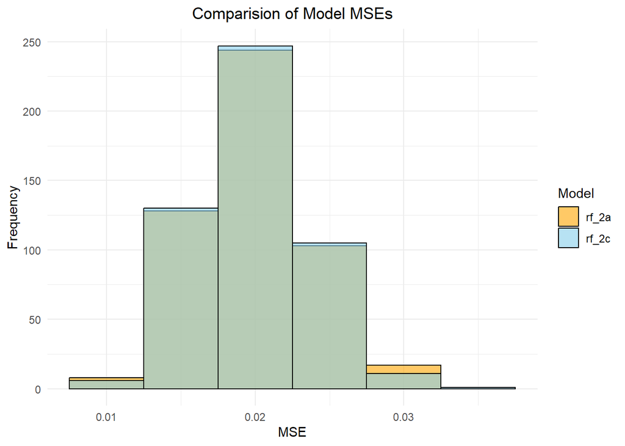

```r
# plotting both histograms together
ggplot(boot_accuracies_df, aes(x = MSE, fill = Model)) +
  geom_histogram(binwidth = 0.005,
                 position = 'identity',
                 alpha = 0.6,
                 color = 'black') +
  labs(title = 'Comparision of Model MSEs',
       x = 'MSE',
       y = 'Frequency') +
  scale_fill_manual(values = c('rf_2a' = 'orange',
                               'rf_2c' = 'skyblue')) +  # Adjust colors as needed
  theme_minimal() +
  theme(plot.title = element_text(hjust = 0.5))
```

The figure shows no difference in MSEs between the random forest model trained with ‘is_terrier’ (rf_2c) and the model trained without (rf_2a). So I am confident the change in model performance between rf_2a (without ‘is_terrier’) and rf_2c (with ‘is_terrier’) occurred by random chance.

##### Therefore the original random forest model was not biased against terriers.

### 3.a.

Conceptually, a K-Nearest Neighbours (KNN) model might be inappropriate for the research question:

- ‘What are the most important factors governing the popularity of a dog breed?’

because we are interested in learning about the features. KNN models only use a simplistic ‘distance’ measure to make predictions. This is significantly less interpretable than a random forest would be where variables can be ranked by importance or even a decision tree where variable importance can be deciphered from the depth of the tree.

Furthermore, the ‘distances’ in KNN here would be calculated on variables which are categorical of 1,2,3,4, or 5. Practically, this means the ‘distances’ calculated by the KNN model would frequently be identical (for a large data set) and have steps between them.

### 3.b.

*Code chunk constructs a KNN model (K=10):*

```r
# constructing KNN model (k=10) on training data
knn_3b = train(popularity ~ grooming_needs+
              playfulness+
              protectiveness+
              barking,
              data = train,
              method = 'knn',
              trControl = ctrl,
              preProcess = c('center', # centering (subtracting the mean)
                             'scale'), # scaling (dividing every point by the standard deviation)
              tuneGrid = expand.grid(k = 10)) # setting k = 10
```

*Code chunk generates out-of-sample MSE for KNN model:*

```r
# getting out of sample predictions
predictions_3b = predict(knn_3b, newdata = test)

# getting out of sample MSE
mse_knn_3b = MSE(actual = test$popularity,
                 predicted = predictions_3b)

# getting R squared
rsquared_3b <- 1 - sum((test$popularity - predictions_3b)^2) / sum((test$popularity - mean(test$popularity))^2)
cat('The out-of-sample R squared is:', rsquared_3b, '\n')
```

```
## The out-of-sample R squared is: 0.1643702
```

```r
# adjusting R squared for data size:
n = nrow(test) # number of rows
k = 4 # number of features

out_of_samp_adj_Rsq_3b = 1 - ((1 - rsquared_3b) * (n - 1) / (n - k - 1))
```

*Code chunk appends results table with KNN model out-of-sample MSE:*

```r
# appending results data frame
regression_results = rbind(regression_results, c('knn_3b', mse_knn_3b, out_of_samp_adj_Rsq_3b))

# resetting as numeric
regression_results$OutofSample_MSE = as.numeric(regression_results$OutofSample_MSE)
regression_results$OutofSample_Adj_R_squared = as.numeric(regression_results$OutofSample_Adj_R_squared)

# Format the numeric columns
regression_results$OutofSample_MSE = sprintf('%.4f', regression_results$OutofSample_MSE)
regression_results$OutofSample_Adj_R_squared = sprintf('%.4f', regression_results$OutofSample_Adj_R_squared)

# making updated kable
kable(regression_results,
      caption = NULL,
      col.names = c('Model', 'Out-of-Sample MSE', 'Out-of-Sample Adjusted R squared'),
      align = 'c',
      format = 'html',
      table.attr = 'style="width:60%;margin:auto;"'   # centring kable
)%>%
  kable_styling(bootstrap_options = c('bordered'))
```

| Model | Out-of-Sample MSE | Out-of-Sample Adjusted R squared |
| --- | --- | --- |
| lm_1c | 0.0192 | 0.1013 |
| lm_1d | 0.0193 | 0.0845 |
| rf_2a | 0.0183 | 0.1440 |
| rf_2c | 0.0191 | 0.0927 |
| knn_3b | 0.0189 | 0.1186 |

### 3.c.

*Code chunk tests different k values to find improved range:*

```r
# visually examining MSEs with elbow curve to find better k value

# setting k values for testing
k_values = c(2, 3, 4, 5, 7, 8, 9, 10, 15, 20, 25, 30, 50)

# making dataframe to store results
knn_3c_results = data.frame(k = numeric(length(k_values)), MSE = numeric(length(k_values)))

# creating loop to store MSE values for each k
for (i in seq_along(k_values)) {
  k = k_values[i]

  # Train the KNN model
  model_3c = train(popularity ~ grooming_needs +
                      playfulness +
                      protectiveness +
                      barking,
                 data = train,
                 method = 'knn',
                 trControl = ctrl,
                 preProcess = c('center', 'scale'),
                 tuneGrid = expand.grid(k = k))

  # Make predictions on the test set
  predictions_3c = predict(model_3c, newdata = test)

  # Calculate Mean Squared Error (MSE)
  mse = MSE(actual = test$popularity,
                 predicted = predictions_3c)

  # Store results in the data frame
  knn_3c_results[i, ] = c(k, mse)
}
```

*Code chunk plots ‘elbow-curve’ for KNN model:*

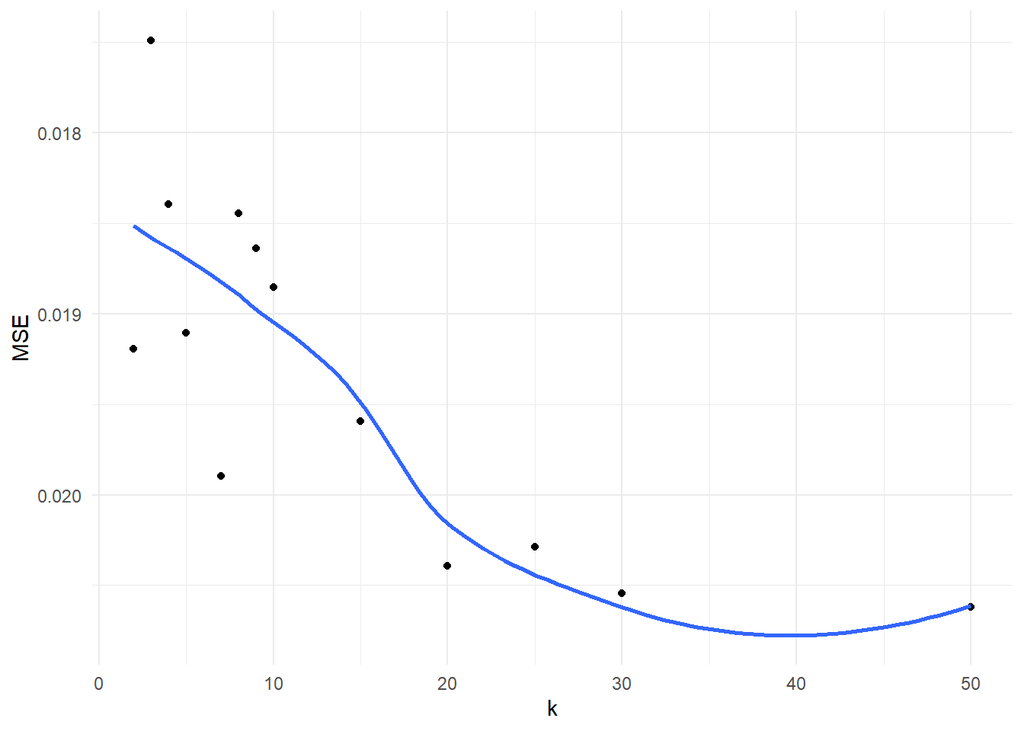

```r
# plotting elbow curve of MSE vs K
ggplot(knn_3c_results, aes(x = k, y = MSE)) +
  geom_point() +  # Add points for the scatter plot
  geom_smooth(method = 'loess', se = FALSE, span = 0.8) +
  theme_minimal() +
  scale_y_reverse() # reversing y scale for aesthetics
```

*Code chunk finds improved KNN model paramters by testing different weight functions and distance values within improved K value range:*

```r
# Training KNN model on different weight functons around optimal k value
# using whole data because of caret's 5 fold cross validation
weights_model_3c = train(
    popularity ~ grooming_needs +
      playfulness +
      protectiveness +
      barking,
    data = dogs, # using whole data set because caret cross validates
    method = 'kknn',
    trControl = ctrl,
    preProcess = c('center', 'scale'),
    tuneGrid = expand.grid(kmax = 15:25, # testing around k = 20
                           distance = 15:30,
                        kernel = c('gaussian',  # different weighting types in kknn
                               'triangular',
                               'rectangular',
                               'epanechnikov',
                               'cos',
                               'optimal'))
  )

# optimal:
# Fitting kmax = 20, distance = 17, kernel = gaussian on full training set
```

Optimal: Fitting kmax = 20, distance = 17, kernel = gaussian on full training set

*Code chunk generates KNN model using improved K, distance, and weight function, and cross validation control:*

```r
# constructing final KNN model using optimised parameters
final_knn_3c = train(
    popularity ~ grooming_needs +
      playfulness +
      protectiveness +
      barking,
    data = dogs,
    method = 'kknn',
    trControl = ctrl,
    preProcess = c('center', 'scale'),
    tuneGrid = expand.grid(kmax = 20, # testing around k = 20
                           distance = 17,
                        kernel = 'gaussian')
  )

# printing MSE and R squared
cat('final_knn_3c MSE:', final_knn_3c$results$RMSE^2, '\n')
```

```
## final_knn_3c MSE: 0.0170746
```

```r
cat('final_knn_3c R squared:', final_knn_3c$results$Rsquared, '\n')
```

```
## final_knn_3c R squared: 0.1529776
```

```r
# adjusting R squared for data size:
n = nrow(dogs) # number of rows
k = 4 # number of features

adj_Rsq_final_knn_3c = 1 - ((1 - final_knn_3c$results$Rsquared) * (n - 1) / (n - k - 1))

cat('final_knn_3c adjusted R squared:', adj_Rsq_final_knn_3c, '\n')
```

```
## final_knn_3c adjusted R squared: 0.1350512
```

*Code chunk appends results table with improved KNN model out-of-sample MSE:*

```r
# appending results data frame
regression_results = rbind(regression_results, c('final_knn_3c', final_knn_3c$results$RMSE^2, adj_Rsq_final_knn_3c))

# resetting as numeric
regression_results$OutofSample_MSE = as.numeric(regression_results$OutofSample_MSE)
regression_results$OutofSample_Adj_R_squared = as.numeric(regression_results$OutofSample_Adj_R_squared)

# Format the numeric columns
regression_results$OutofSample_MSE = sprintf('%.4f', regression_results$OutofSample_MSE)
regression_results$OutofSample_Adj_R_squared = sprintf('%.4f', regression_results$OutofSample_Adj_R_squared)

# making updated kable
kable(regression_results,
      caption = NULL,
      col.names = c('Model', 'Out-of-Sample MSE', 'Out-of-Sample Adjusted R squared'),
      align = 'c',
      format = 'html',
      table.attr = 'style="width:60%;margin:auto;"'   # centring kable
)%>%
  kable_styling(bootstrap_options = c('bordered'))
```

| Model | Out-of-Sample MSE | Out-of-Sample Adjusted R squared |
| --- | --- | --- |
| lm_1c | 0.0192 | 0.1013 |
| lm_1d | 0.0193 | 0.0845 |
| rf_2a | 0.0183 | 0.1440 |
| rf_2c | 0.0191 | 0.0927 |
| knn_3b | 0.0189 | 0.1186 |
| final_knn_3c | 0.0171 | 0.1351 |

### 4.

```r
# retrieving the variable importances from  final_knn_3c with permutations

fitted_final_knn_3c <- final_knn_3c$finalModel

# making prediction function for pred_wrapper argument
predict_function <- function(model, newdata) {
  predict(model, newdata = newdata)
}

# Compute variable importances using the vip package
importance <- vip::vi(fitted_final_knn_3c,
                      method = "permute",
                      train = dogs,
                      target = dogs$popularity,
                      metric = "rmse", # using rmse for metric
                      smaller_is_better = TRUE, # lower rmse is better
                      pred_wrapper = predict_function)

# Print the variable importances
print(importance)
```

```
## # A tibble: 20 × 2
##    Variable                 Importance
##    <chr>                         <dbl>
##  1 playfulness                0.00108
##  2 grooming_needs             0.000976
##  3 affection                  0
##  4 good_with_young_children   0
##  5 good_with_other_dogs       0
##  6 shedding                   0
##  7 drool                      0
##  8 coat_type                  0
##  9 coat_length                0
## 10 openness_to_strangers      0
## 11 adaptability               0
## 12 trainability_level         0
## 13 energy                     0
## 14 mental_stimulation_needs   0
## 15 breed_clean                0
## 16 popularity                 0
## 17 editors_choice             0
## 18 is_terrier                 0
## 19 barking                   -0.000112
## 20 protectiveness            -0.00386
```

‘playfulness’ is the most important feature here. With ‘grooming_needs’ second, ‘barking’ third, and ‘protectiveness’ fourth.

Given the model scores, no I do not believe the model is good at predicting the popularity of dogs. The adjusted R squareds for all the models were low (<0.2), this was the just best option of those models.

I think this is due to the variable nature of the data, the non continuous nature of the data, and the small size of the data.

# Classification: ‘How can you tell if a dog is an ’Editor’s choice?’

### 1.a.

*Code chunk fits decision tree model:*

```r
# making decision tree with minimum leaf size of 10

# making new ctrl object with arguments for decision trees
ctrl_1a = trainControl(method = 'cv',
                     number = 5,
                     classProbs = TRUE, # to calculate class probabilities
                     summaryFunction = twoClassSummary,
                     # should weight true positive and negatives equally
                     verboseIter = FALSE,
                     savePredictions = 'final' # storing performance for each fold for examining
                     )

# setting editors_choice as a factor for classification
dogs$factor_editors_choice = as.factor(dogs$editors_choice)
dogs$factor_editors_choice = factor(make.names(as.character(dogs$factor_editors_choice)))

# using the whole data because of cross validation in control method
tree_1a_c = caret::train(
  x = dogs[, c('grooming_needs',
               'playfulness',
               'protectiveness',
               'barking',
               'popularity')],
  y = dogs$factor_editors_choice,
  method = 'rpart',
  trControl = ctrl_1a,
  tuneLength = 10, # sets how many different values for the main parameter
  control = rpart::rpart.control(minbucket = 10) # minimum leaf size
  )
# rpart uses ROC instead of accuracy to optimise

# setting no other constraints (eg. tuneGrid, cp range etc) to let caret train find optimal
tree_1a_c
```

```
## CART
##
## 194 samples
##   5 predictor
##   2 classes: 'X0', 'X1'
##
## No pre-processing
## Resampling: Cross-Validated (5 fold)
## Summary of sample sizes: 155, 156, 154, 155, 156
## Resampling results across tuning parameters:
##
##   cp           ROC        Sens       Spec
##   0.000000000  0.6055654  0.8583744  0.27272727
##   0.007122507  0.6055654  0.8583744  0.27272727
##   0.014245014  0.6055654  0.8583744  0.27272727
##   0.021367521  0.6055654  0.8583744  0.27272727
##   0.028490028  0.6055654  0.8583744  0.27272727
##   0.035612536  0.6055654  0.8583744  0.27272727
##   0.042735043  0.6055654  0.8583744  0.27272727
##   0.049857550  0.5789420  0.8940887  0.23636364
##   0.056980057  0.5789420  0.8940887  0.23636364
##   0.064102564  0.5614420  0.9655172  0.07636364
##
## ROC was used to select the optimal model using the largest value.
## The final value used for the model was cp = 0.04273504.
```

```r
tree_1a_c$final
```

```
## n= 194
##
## node), split, n, loss, yval, (yprob)
##       * denotes terminal node
##
##  1) root 194 52 X0 (0.7319588 0.2680412)
##    2) popularity< 0.8685353 112 19 X0 (0.8303571 0.1696429) *
##    3) popularity>=0.8685353 82 33 X0 (0.5975610 0.4024390)
##      6) grooming_needs>=2.5 32  7 X0 (0.7812500 0.2187500) *
##      7) grooming_needs< 2.5 50 24 X1 (0.4800000 0.5200000)
##       14) popularity>=0.9176306 28 10 X0 (0.6428571 0.3571429) *
##       15) popularity< 0.9176306 22  6 X1 (0.2727273 0.7272727) *
```

### 1.b.

*Code chunk prints decision tree:*

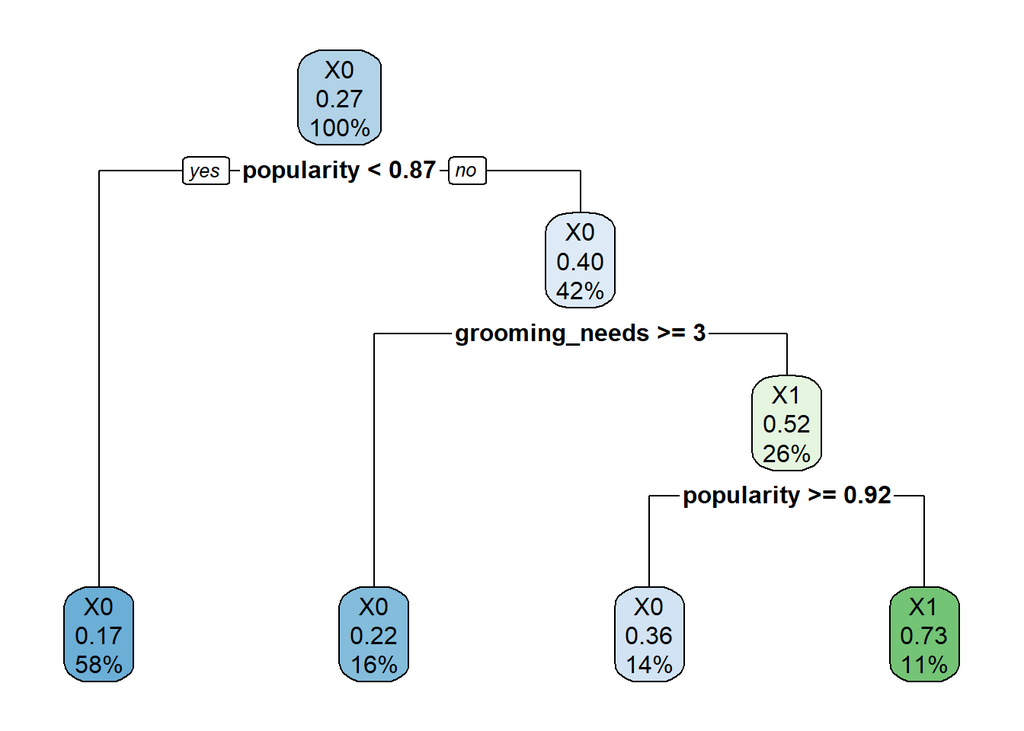

```r
rpart.plot(tree_1a_c$finalModel)
```

In plain language, here is the decision tree route to the terminal node which predicts a dog is an editor’s choice:

The data is first split on the condition of whether popularity score less than 0.87. If the popularity score is greater than, or equal to, 0.87, then the data is split again on the condition of ‘is the grooming score greater than, or equal to, 3’. If this condition is not met, then the data is split again on the condition ‘is the popularity score greater than or equal to 0.92’. If this condition is not met, then the dogs are predicted to be editor’s choice with a 73% accuracy.

### 1.c.

*Code chunk makes new training and test data with specified split:*

```r
# setting new test and train data sets with 33% in the test data

# setting different random seed
set.seed(2)

# making new training data
train_1c_c = dogs %>%
  select(c('grooming_needs', 'playfulness', 'protectiveness', 'barking', 'popularity', 'factor_editors_choice')) %>%
  sample_frac(0.67)

# making new test data
test_1c_c = dogs %>%
  select(c('grooming_needs', 'playfulness', 'protectiveness', 'barking', 'popularity', 'factor_editors_choice')) %>%
  anti_join(., train_1c_c)
```

*Code chunk generates decision tree with new split:*

```r
# creating new decision tree with training data
tree_1c_c = caret::train(
  x = train_1c_c[, c('grooming_needs',
               'playfulness',
               'protectiveness',
               'barking',
               'popularity')],
  y = train_1c_c$factor_editors_choice,
  method = 'rpart',
  trControl = ctrl_1a,
  tuneLength=10,
  control = rpart::rpart.control(minbucket = 10)
  )
```

*Code chunk generates confusion matrix and accuracy value for decision tree:*

```r
# getting out of sample predictions
predictions_1c_c = predict(tree_1c_c, newdata = test_1c_c)

# making a confusion matrix
confusion_mat = confusionMatrix(predictions_1c_c, reference = test_1c_c$factor_editors_choice)

# Print the confusion matrix
print(confusion_mat)
```

```
## Confusion Matrix and Statistics
##
##           Reference
## Prediction X0 X1
##         X0 46 18
##         X1  0  0
##
##                Accuracy : 0.7188
##                  95% CI : (0.5924, 0.824)
##     No Information Rate : 0.7188
##     P-Value [Acc > NIR] : 0.5631
##
##                   Kappa : 0
##
##  Mcnemar's Test P-Value : 6.151e-05
##
##             Sensitivity : 1.0000
##             Specificity : 0.0000
##          Pos Pred Value : 0.7188
##          Neg Pred Value :    NaN
##              Prevalence : 0.7188
##          Detection Rate : 0.7188
##    Detection Prevalence : 1.0000
##       Balanced Accuracy : 0.5000
##
##        'Positive' Class : X0
##
```

```r
as.table(confusion_mat)
```

```
##           Reference
## Prediction X0 X1
##         X0 46 18
##         X1  0  0
```

```r
# printing accuracy
accuracy = confusion_mat$overall['Accuracy']
cat('Overall Accuracy:', accuracy, '\n')
```

```
## Overall Accuracy: 0.71875
```

### 1.d.

Could look for optimal split by looping through different splits in different seeds but not much benefit and finding the optimal split for one seed creates artificial accuracy, that is not reproducible.

*Code chunk generates new training and test data with different split:*

```r
set.seed(3) # different random seed

# remaking train and test data with 50-50 split
train_1d_c = dogs %>%
  select(c('grooming_needs', 'playfulness', 'protectiveness', 'barking', 'popularity', 'factor_editors_choice')) %>%
  sample_frac(0.8) # small data set so using 60-40 split so that test data isnt too small


test_1d_c = dogs %>%
  select(c('grooming_needs', 'playfulness', 'protectiveness', 'barking', 'popularity', 'factor_editors_choice')) %>%
  anti_join(., train_1c_c)
```

*Code chunk regenerates decision tree with new test and train split:*

```r
# recreating decision tree with new split
# creating new decision tree with training data
tree_1d_c = caret::train(
  x = train_1d_c[, c('grooming_needs',
               'playfulness',
               'protectiveness',
               'barking',
               'popularity')],
  y = train_1d_c$factor_editors_choice,
  method = 'rpart',
  trControl = ctrl_1a,
  tuneLength=10,
  control = rpart::rpart.control(minbucket = 10)
  )
```

*Code chunk prints confusion matrix and accuracy for new decision tree:*

```r
# getting out of sample predictions
predictions_1d_c = predict(tree_1d_c, newdata = test_1d_c)

# making a confusion matrix
confusion_mat_1d = confusionMatrix(predictions_1d_c, reference = test_1d_c$factor_editors_choice)

# Print the confusion matrix
#print(confusion_mat_1d)
as.table(confusion_mat_1d)
```

```
##           Reference
## Prediction X0 X1
##         X0 40 10
##         X1  6  8
```

```r
# printing accuracy
accuracy_1d = confusion_mat_1d$overall['Accuracy']
cat('Overall Accuracy for 1d:', accuracy_1d, '\n')
```

```
## Overall Accuracy for 1d: 0.75
```

```r
#printing consuion matrix from 1c
as.table(confusion_mat)
```

```
##           Reference
## Prediction X0 X1
##         X0 46 18
##         X1  0  0
```

```r
# printing accuracy from 1c
cat('Overall Accuracy for 1c:', accuracy, '\n')
```

```
## Overall Accuracy for 1c: 0.71875
```

### 1.e.

*Code chunk generates predictions for the whole data set from the decision tree:*

```r
# Getting predictions for whole dogs data set from tree_1d_c
predictions_1e_c = predict(tree_1d_c, newdata = dogs)

# add predictions from tree_1d_c to dogs
dogs$predictions_1e_c = predictions_1e_c
```

*Code chunk prints table of the average popularity for each prediction type:*

```r
# grouping by
table_1e_c = dogs %>%
  group_by(editors_choice, predictions_1e_c) %>%
  summarize(AveragePopularity = mean(popularity)) %>%
  mutate(PredictionType = case_when(
    editors_choice == 0 & predictions_1e_c == 'X0' ~ 'True Negative',
    editors_choice == 0 & predictions_1e_c == 'X1' ~ 'False Positive',
    editors_choice == 1 & predictions_1e_c == 'X0' ~ 'False Negative',
    editors_choice == 1 & predictions_1e_c == 'X1' ~ 'True Positive'
  ))

table_1e_c %>%
  kable(.,
      caption = NULL,
      col.names = c('Observed Choice', 'Predicted Value', 'Average Popularity', 'Prediction Type'),
      align = 'c',  # Center-align columns
      format = 'html',
      table.attr = 'style="width:60%;margin:auto;"'  # centres table in page
      ) %>%
  kable_styling(bootstrap_options = c('bordered'))
```

| Observed Choice | Predicted Value | Average Popularity | Prediction Type |
| --- | --- | --- | --- |
| 0 | X0 | 0.7709496 | True Negative |
| 0 | X1 | 0.9340948 | False Positive |
| 1 | X0 | 0.8184324 | False Negative |
| 1 | X1 | 0.9220249 | True Positive |

The dogs that are predicted to be editor’s choice have a high average popularity (>0.92). This is true for false positives and true positives. The false positives having the same average popularity as the true positives indicates popularity might be overused as a predictor. However, false negatives have a higher average popularity than true negatives which tells us the model is not only assigning its predictions based on popularity or else all lower popularity dogs would be predicted as no editor’s choice. The model may not be flexible enough to find the non-linear relationships between the variables. Furthermore, the variability of the data and small sample size make it difficult for the model to be highly trained.

Note: it is not suprising that the model relies heavily on popluarity since the other features were selected for predicting popluarity.

### 2.a.

*Code chunk generates a logistic regression model:*

```r
# fitting logistic regression
ctrl_2a = trainControl(method = 'cv', number = 5, classProbs = TRUE, summaryFunction = twoClassSummary)
# check if can use the same ctrl as above

# Train the logistic regression model using caret::train()
log_reg_model = train(x = train_1d_c[, c('grooming_needs', # using the same training data as 1d
               'playfulness',
               'protectiveness',
               'barking',
               'popularity')],
  y = train_1d_c$factor_editors_choice,
                       method = 'glm',
                       trControl = ctrl_2a,
                       family = binomial() # along with glm this sets the model to be logistic regression
  )
log_reg_model
```

```
## Generalized Linear Model
##
## 155 samples
##   5 predictor
##   2 classes: 'X0', 'X1'
##
## No pre-processing
## Resampling: Cross-Validated (5 fold)
## Summary of sample sizes: 123, 124, 125, 124, 124
## Resampling results:
##
##   ROC        Sens       Spec
##   0.6776186  0.9735178  0.1444444
```

*Code chunk prints confusion matrix and model accuracy for the logistic regression model:*

```r
# generating predictions to get confusion matrix
predictions_2a_c = predict(log_reg_model, newdata = test_1d_c)

# making confusion matrix
confusion_mat_2a_c = confusionMatrix(predictions_2a_c, reference = test_1d_c$factor_editors_choice)

# Print the confusion matrix
#print(confusion_mat_2a_c)
as.table(confusion_mat_2a_c)
```

```
##           Reference
## Prediction X0 X1
##         X0 44 17
##         X1  2  1
```

```r
# printing accuracy
accuracy_2a_c = confusion_mat_2a_c$overall['Accuracy']
cat('Overall Accuracy for 2a:', accuracy_2a_c, '\n')
```

```
## Overall Accuracy for 2a: 0.703125
```

```r
cat('\n')
```

```r
cat('\n')
```

```r
# printing confusion matrix of 1d
as.table(confusion_mat_1d)
```

```
##           Reference
## Prediction X0 X1
##         X0 40 10
##         X1  6  8
```

```r
# printing accuracy of 1d
cat('Overall Accuracy for 1d:', accuracy_1d, '\n')
```

```
## Overall Accuracy for 1d: 0.75
```

The accuracies of the model are similar however the decision tree was higher. Given a decision tree interpretability of a decision tree, it is the preferred model in this case.

### 2.b.

*Code chunk regenerates logistic regression using bootstrapping method (instead of cross validation):*

```r
# setting bootstrap control method
ctrl_boot_c = trainControl(method = 'boot', number = 1000) # 1000 bootstraps

# training logistic regression models with bootstrap resampling
log_reg_boot = train(x = train_1d_c[, c('grooming_needs', 'playfulness', 'protectiveness', 'barking', 'popularity')],
                          y = train_1d_c$factor_editors_choice,
                          method = 'glm',
                          trControl = ctrl_boot_c,
                          family = binomial())
log_reg_boot
```

```
## Generalized Linear Model
##
## 155 samples
##   5 predictor
##   2 classes: 'X0', 'X1'
##
## No pre-processing
## Resampling: Bootstrapped (1000 reps)
## Summary of sample sizes: 155, 155, 155, 155, 155, 155, ...
## Resampling results:
##
##   Accuracy   Kappa
##   0.7287037  0.1353519
```

*Code chunk prints range of accuracies of bootstrap logistric regression models:*

```r
# getting out of sample predictions
predictions_2b_c = predict(log_reg_boot, newdata = test_1d_c)

# printing confusion matrix
confusion_mat_2b_c = confusionMatrix(predictions_2b_c, reference = test_1d_c$factor_editors_choice)

# print(confusion_mat_2b_c)
as.table(confusion_mat_2b_c)
```

```
##           Reference
## Prediction X0 X1
##         X0 44 17
##         X1  2  1
```

```r
# getting accuracies for every bootstrap iteration
boot_accuracies = log_reg_boot$resample$Accuracy

# Print the range of accuracies
cat('Range of logistic regression bootstrap accuracies: ', min(boot_accuracies), '-', max(boot_accuracies), '\n')
```

```
## Range of logistic regression bootstrap accuracies:  0.537037 - 0.8833333
```

*Code chunk generates histogram of bootsrapped logistic regression accuracies:*

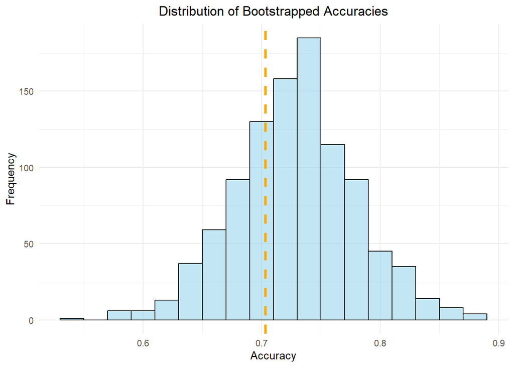

```r
# plotting accuracies for bootstrap
ggplot(data.frame(Accuracy = boot_accuracies), aes(x = Accuracy)) +
  geom_histogram(binwidth = 0.02,
                 fill = 'skyblue',
                 color = 'black',
                 alpha = 0.5) +
  labs(title = 'Distribution of Bootstrapped Accuracies',
       x = 'Accuracy',
       y = 'Frequency') +
    geom_vline(xintercept = 0.703125,
               linetype = "dashed",
               color = "orange",
               size = 1.2) +  # line to show accuracy of log_reg_model
  theme_minimal() +
  theme(plot.title = element_text(hjust = 0.5))
```

The accuracy of the model from 2a (log_reg_model) is denoted by the dashed orange line and falls within the expected accuracies of the bootstrapped models, although slightly below average. This would not usually be expected since the range of bootstrapped accuracies should generally fall lower than the final model. This reflects that the original model might not perform very well.

### 3.

*Code chunk fits random forest model:*

```r
randfor_3 = train(x = train_1d_c[, c('grooming_needs',
                                     'playfulness',
                                     'protectiveness',
                                     'barking',
                                     'popularity')],
                  y = train_1d_c$factor_editors_choice,
                  method = 'rf',
                  trControl = ctrl
                  )
randfor_3
```

```
## Random Forest
##
## 155 samples
##   5 predictor
##   2 classes: 'X0', 'X1'
##
## No pre-processing
## Resampling: Cross-Validated (5 fold)
## Summary of sample sizes: 124, 125, 123, 124, 124
## Resampling results across tuning parameters:
##
##   mtry  Accuracy   Kappa
##   2     0.7284946  0.1729847
##   3     0.7218145  0.1823959
##   5     0.7411828  0.2338312
##
## Accuracy was used to select the optimal model using the largest value.
## The final value used for the model was mtry = 5.
```

*Code chunk prints confusion matrix and accuracy for random forest model:*

```r
# getting predictions for out of sample accuracy
predictions_3_c = predict(randfor_3, newdata = test_1d_c)

# making confusion matrix
confusion_mat_3_c = confusionMatrix(predictions_3_c, reference = test_1d_c$factor_editors_choice)

# Print the confusion matrix
print(confusion_mat_3_c)
```

```
## Confusion Matrix and Statistics
##
##           Reference
## Prediction X0 X1
##         X0 43  4
##         X1  3 14
##
##                Accuracy : 0.8906
##                  95% CI : (0.7875, 0.9549)
##     No Information Rate : 0.7188
##     P-Value [Acc > NIR] : 0.0008142
##
##                   Kappa : 0.7248
##
##  Mcnemar's Test P-Value : 1.0000000
##
##             Sensitivity : 0.9348
##             Specificity : 0.7778
##          Pos Pred Value : 0.9149
##          Neg Pred Value : 0.8235
##              Prevalence : 0.7188
##          Detection Rate : 0.6719
##    Detection Prevalence : 0.7344
##       Balanced Accuracy : 0.8563
##
##        'Positive' Class : X0
##
```

```r
as.table(confusion_mat_3_c)
```

```
##           Reference
## Prediction X0 X1
##         X0 43  4
##         X1  3 14
```

```r
# printing accuracy
accuracy_3_c = confusion_mat_3_c$overall['Accuracy']
cat('Overall Accuracy:', accuracy_3_c, '\n')
```

```
## Overall Accuracy: 0.890625
```

*Code chunk recreates random forest model using bootstrapping (instead of cross validation):*

```r
# trying again with bootstrapping method
randfor_3_boot = train(x = train_1d_c[, c('grooming_needs',
                                          'playfulness',
                                          'protectiveness',
                                          'barking',
                                          'popularity')],
                  y = train_1d_c$factor_editors_choice,
                  method = 'rf',
                  trControl = ctrl_boot_c # using bootstrap method now
                  )
```

*Code chunk confusion matrix and accuracy of bootstrapped random forest model:*

```r
# getting predictions for out of sample accuracy
predictions_3_boot = predict(randfor_3_boot, newdata = test_1d_c)

# making confusion matrix
confusion_mat_3_boot = confusionMatrix(predictions_3_boot, reference = test_1d_c$factor_editors_choice)

# Print the confusion matrix
#print(confusion_mat_3_boot)
as.table(confusion_mat_3_boot)
```

```
##           Reference
## Prediction X0 X1
##         X0 43  4
##         X1  3 14
```

```r
# printing accuracy
accuracy_3_boot = confusion_mat_3_boot$overall['Accuracy']
cat('Overall Accuracy:', accuracy_3_boot, '\n')
```

```
## Overall Accuracy: 0.890625
```

*Code chunk prints all previous confusion matracies and associated model accuracies:*

```r
# reprinting all the confusion matracies:

# decision tree (33/67)
cat('decision tree (33/67):','\n')
```

```
## decision tree (33/67):
```

```r
as.table(confusion_mat)
```

```
##           Reference
## Prediction X0 X1
##         X0 46 18
##         X1  0  0
```

```r
cat('Overall Accuracy:', accuracy, '\n')
```

```
## Overall Accuracy: 0.71875
```

```r
cat('\n') # aadds line break for clearer printing
```

```r
cat('\n')
```

```r
# decision tree (50/50 split)
cat('decision tree (50/50):','\n')
```

```
## decision tree (50/50):
```

```r
as.table(confusion_mat_1d)
```

```
##           Reference
## Prediction X0 X1
##         X0 40 10
##         X1  6  8
```

```r
cat('Overall Accuracy:', accuracy_1d, '\n')
```

```
## Overall Accuracy: 0.75
```

```r
cat('\n')
```

```r
cat('\n')
```

```r
# logistic regression
cat('logistic regression:','\n')
```

```
## logistic regression:
```

```r
as.table(confusion_mat_2a_c)
```

```
##           Reference
## Prediction X0 X1
##         X0 44 17
##         X1  2  1
```

```r
cat('Overall Accuracy:', accuracy_2a_c, '\n')
```

```
## Overall Accuracy: 0.703125
```

```r
cat('\n')
```

```r
cat('\n')
```

```r
# random forest (cross validated)
cat('random forest (cross validated):','\n')
```

```
## random forest (cross validated):
```

```r
as.table(confusion_mat_3_c)
```

```
##           Reference
## Prediction X0 X1
##         X0 43  4
##         X1  3 14
```

```r
cat('Overall Accuracy:', accuracy_3_c, '\n')
```

```
## Overall Accuracy: 0.890625
```

```r
cat('\n')
```

```r
cat('\n')
```

```r
# random forest (bootstrapped)
cat('random forest (bootstrapped):','\n')
```

```
## random forest (bootstrapped):
```

```r
as.table(confusion_mat_3_boot)
```

```
##           Reference
## Prediction X0 X1
##         X0 43  4
##         X1  3 14
```

```r
cat('Overall Accuracy:', accuracy_3_boot, '\n')
```

```
## Overall Accuracy: 0.890625
```

The random forest models performed the best by far in terms of accuracy. Notably the main improvement appears to be the correct prediction of true positives, which the other models struggled with. This indicates the random forest model was able to better capture the non-linear relationship between these variables and whether or not a dog is an editors choice.

Note: the variables used here were selected for predicting popularity so the results could have been improved if feature selection had been done with editor choice prediction in mind.

### 4.a

The models with the highest accuracy (0.89) were the two random forest models. Since the cross validated model was considerably less computationally intensive to generate, it is the preferred model for classifying if a dog is an editors choice or not.

This model was constructed using 5 fold cross validation to improve its out of sample predictive reliability.

*Code chunk prints accuracies of each fold in the random forest model cross validation:*

```r
# printing the accuracies of the 5 folds in randfor_3
cat(randfor_3$resample$Accuracy, sep = "\n")
```

```
## 0.7419355
## 0.8064516
## 0.75
## 0.6333333
## 0.7741935
```

Clearly the cross validation method was effective since the accuracies of each individual fold was lower (0.63 - 0.81). This is expected since each fold is not trained on the whole data. The range of accuracies was large because the data set was small and therefore any subsetting of this can cause significant random deviation.

The final accuracy is somewhat relaible due to the 5 fold cross validation and that is was equal to the bootstrapping method. However, it is highly variable under subsetting of the data

### 4.b.

*Code chunk prints accuracies of each fold in the decision tree model cross validation:*

```r
# Accuracy is not a default output of rpart trees so calculating accuracies per fold.

# setting control so that i can get results per fold
ctrl_4_c <- trainControl(
  method = 'cv',
  number = 5,
  index = createFolds(train_1d_c$factor_editors_choice, k = 5),
  verboseIter = FALSE
)

# making empty list to store confusion matrices
confusion_matrices <- list()

# looping through each fold
for (i in seq_along(ctrl_4_c$index)) {

  # getting train and test for every fold
  train_indices <- ctrl_4_c$index[[i]]
  test_indices <- setdiff(1:nrow(train_1d_c), train_indices)

  # Create training and testing datasets
  train_4_c <- train_1d_c[train_indices, ]
  test_4_c <- train_1d_c[test_indices, ]

  # Train the model on the current fold
  tree_1d_c_fold <- train(
    x = train_4_c[, c('grooming_needs',
                       'playfulness',
                       'protectiveness',
                       'barking',
                       'popularity')],
    y = factor(train_4_c$factor_editors_choice,
               levels = levels(train_1d_c$factor_editors_choice)),
    method = "rpart",
    trControl = ctrl_4_c,
    tuneLength = 5
  )

  # making predictions for current fold
  predictions <- predict(tree_1d_c_fold, newdata = test_4_c)
  # making sure predictions is as a factor
  predictions <- factor(predictions, levels = levels(train_1d_c$factor_editors_choice))

  # making the confusion matrices
  confusion_matrix <- confusionMatrix(predictions, reference = test_4_c$factor_editors_choice)

  # storing confusion matrices in the list
  confusion_matrices[[i]] = confusion_matrix
}

# printing all confusion matrices (gives accuracy)
for (i in seq_along(confusion_matrices)) {
  cat("Confusion Matrix for Fold", i, ":\n")
  print(confusion_matrices[[i]])
  cat("\n")
}
```

```
## Confusion Matrix for Fold 1 :
## Confusion Matrix and Statistics
##
##           Reference
## Prediction X0 X1
##         X0 91 33
##         X1  0  0
##
##                Accuracy : 0.7339
##                  95% CI : (0.647, 0.8092)
##     No Information Rate : 0.7339
##     P-Value [Acc > NIR] : 0.5467
##
##                   Kappa : 0
##
##  Mcnemar's Test P-Value : 2.54e-08
##
##             Sensitivity : 1.0000
##             Specificity : 0.0000
##          Pos Pred Value : 0.7339
##          Neg Pred Value :    NaN
##              Prevalence : 0.7339
##          Detection Rate : 0.7339
##    Detection Prevalence : 1.0000
##       Balanced Accuracy : 0.5000
##
##        'Positive' Class : X0
##
##
## Confusion Matrix for Fold 2 :
## Confusion Matrix and Statistics
##
##           Reference
## Prediction X0 X1
##         X0 91 32
##         X1  0  0
##
##                Accuracy : 0.7398
##                  95% CI : (0.653, 0.8148)
##     No Information Rate : 0.7398
```

[output cut: 89 more lines]

```
##                   Kappa : 0
##
##  Mcnemar's Test P-Value : 2.54e-08
##
##             Sensitivity : 1.0000
##             Specificity : 0.0000
##          Pos Pred Value : 0.7339
##          Neg Pred Value :    NaN
##              Prevalence : 0.7339
##          Detection Rate : 0.7339
##    Detection Prevalence : 1.0000
##       Balanced Accuracy : 0.5000
##
##        'Positive' Class : X0
##
```

NOTE: The ‘rpart’ method in caret::train() does not automatically calculate accuracy when cross validating the model so above I have retrained the decision tree model in a 5 fold cross validation method and the associated accuracies and confusion matrices have been printed. These should be the same as the cross validation models ran in question 1.d. since the random seed has not been altered.

The accuracies of the decision tree model folds are extremely similar (0.7339 - 0.7398) which implies the decision tree’s results are highly reliable. Significantly more reliable than the random forest model where the fold accuraccies were between 0.6333 and 0.8065.

Model selection depends on the goal:

- The out-sample-accuracy for the random forest model (randfor_3) was 0.89 and the out-sample-accuracy for the decision tree model (tree_1d_c) was 0.75 so if the most accurate out-of-sample predictions is the goal then randfor_3 should be selected.
- However, if the goal is risk mitigation then, due to the more flexible nature of random forest models, tree_1d_c should be selected as the cross validation fold accuracies were significantly more similar.